# **- ATOC 568 -** **Modelling lab**

# Session #1: Getting started with the model and running the control experiment

### Objectives

- Setting up of the global configuration
- Run of the control simulation
- Preliminary analyses of the control simulation output

## I. Installation of the configuration

### I.1. Download the code

Open a terminal from the launch page and type:

`git clone https://github.com/MITgcm/MITgcm.git`

This will download the latest available code.

[**Git**](https://git-scm.com/) is a version control software tool used to help coordinate work on documents, computer programs, large websites and other collection of information among many contributors. Version control is a management system to track changes in, for example, code over time, not only facilitating ongoing changes to code, but also as a means to check differences and/or obtain code from any past time in the project history. It allows to keep track of bug fixes and new features submitted by the global network of contributors.

Then go to your MITgcm directory:

`cd MITgcm`

Here is a brief description of the directories of the model:

- **model**: contains the main source code, subdivided into two subdirectories: `model/inc` (includes files) and `model/src` (source code).
- **eesupp**: contains the execution environment source code. Also subdivided into two subdirectories: `eesupp/inc` and `eesupp/src`.
- **pkg**: contains the source code for the packages. Each package corresponds to a subdirectory. For example, `pkg/gmredi` contains the code related to the Gent-McWilliams/Redi scheme, `pkg/seaice` the code for a dynamic sea ice model which can be coupled to the ocean model.
- **doc**: contains MITgcm documentation.
- **tools**: contains various useful tools. For example, `genmake2` is a script written in bash that should be used to generate your makefile. The subdirectory `tools/build_options` contains "optfiles" with compiler options for many different compilers and machines that can run MITgcm.
- **utils**: contains various utilities. The `utils/matlab` subdirectory contains matlab scripts for reading model output directly into matlab. The subdirectory `utils/python` contains similar routines for python. `utils/scripts` contains C-shell post-processing scripts for joining processor-based and tiled-based model output.
- **verification**: this directory contains the model examples.
- **jobs**: contains sample job scripts for running MITgcm.
- **lsopt**: Line search code used for optimization.
- **optim**: Interface between MITgcm and line search code.

### I.2. Build the model configuration

We will build our model configuration from a tutorial example experiment called [tutorial_global_oce_latlon](https://mitgcm.readthedocs.io/en/latest/examples/global_oce_latlon/global_oce_latlon.html). To do so, copy the verification directory `tutorial_global_oce_latlon` (in `MITgcm/verification/`) into a new directory (give it the name you want; e.g. `my_exp`), then go to this directory:

`cp -r verification/tutorial_global_oce_latlon/* my_exp`  
`cd my_exp`

Go to the directory code (`MITgcm/my_exp/code`):

`cd code`

There, you will find the source files of the model which are specific to this global configuration and which you can modify for your experiment.

**SIZE.h** declares the size of the domain. Your domain is divided into tiles of dimensions `sNx` and `sNy`, with each tile corresponding to a specific region of the physical space. Each processor is allocated `nSx` $\times$ `nSy` tiles. This way, the computational work is divided among the logical processors by allocating “ownership” to each processor of a certain set of calculations. In our experiment, we will only use one processor (`nPx=1`; `nPy=1`) with the following parameters: `sNx=45`; `sNy=40`; `nSx=2`; `nSy=1`

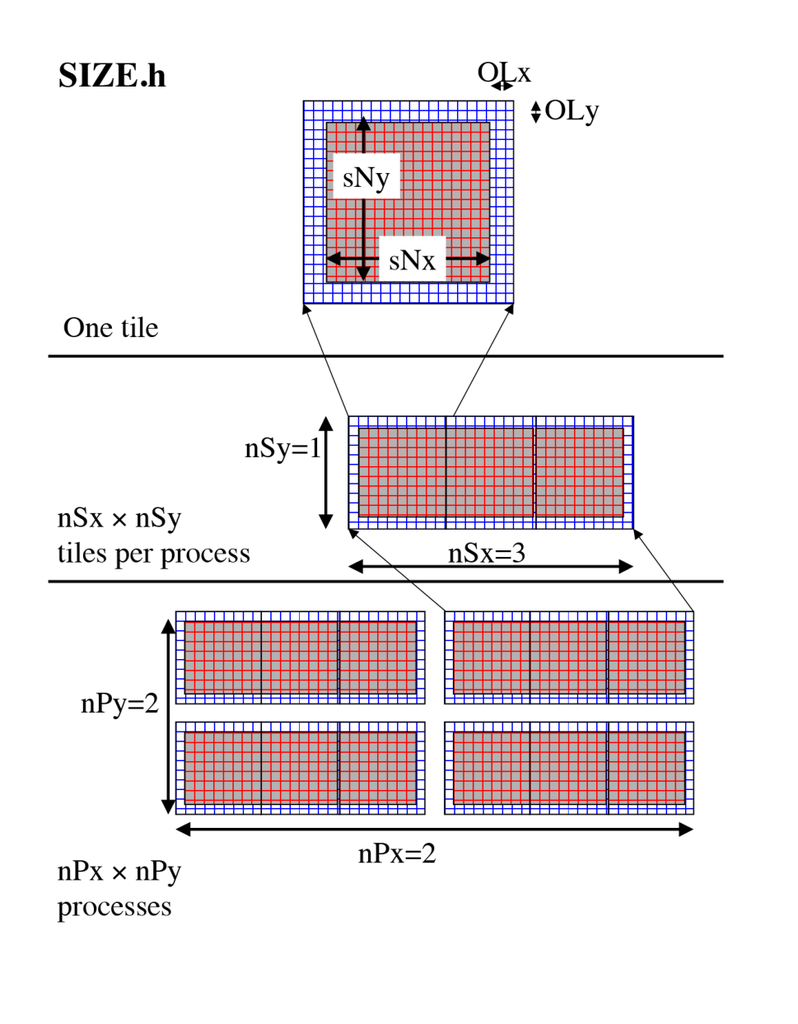

Fig. 1: See caption [here](https://mitgcm.readthedocs.io/en/latest/software_arch/software_arch.html#specifying-a-domain-decomposition) (source: MITgcm doc)

Make a schematic of our domain decomposition inspired from the figure.

We have 15 points in the vertical direction (Nr).

Caculate the total number of points in our domain.

Documentation: More on [domain decomposition](https://mitgcm.readthedocs.io/en/latest/software_arch/software_arch.html#specifying-a-domain-decomposition) and [model parallelism](https://mitgcm.readthedocs.io/en/latest/software_arch/software_arch.html#machine-model-parallelism).

**packages.conf** lists the packages you need to use for the configuration:

- `gfd` is the standard geophysical fluid dynamics package which contains a group of packages (`mom_common`, `mom_fluxform`, `mom_vecinv`, `generic_advdiff`, `debug`, `mdsio`, `rw`, `monitor`)
- `gmredi` is the [Gent-McWilliams/Redi SGS Eddy Parameterization package](https://mitgcm.readthedocs.io/en/latest/phys_pkgs/gmredi.html). Gent and McWilliams (GM) scheme is proposed to parameterize effects of geostrophic eddies in non-eddy resolving models.
- `cd_code` is for the treatment of the Coriolis terms in C-grid models at low-resolution
- `timeave` gives output averaged over a period. This is an old package that we will replace by the package `diagnostics`
- `ptracers` is a “passive” [tracer package](https://mitgcm.readthedocs.io/en/latest/phys_pkgs/ptracers.html). Passive refers to tracers that do not affect the density of the water (as opposed to temperature and salinity) so they do not affect the physics of the ocean. Ages of water masses will be estimated with an age tracer, which is restored to zero at the surface.
- `mnc` is the [NetCDF package](https://mitgcm.readthedocs.io/en/latest/outp_pkgs/outp_pkgs.html#netcdf-i-o-pkg-mnc) to save output in [NetCDF format](https://docs.unidata.ucar.edu/netcdf-c/current/index.html).

To use the package `diagnostics`:

1. Edit `packages.conf` by adding a line:  
   `diagnostics`
2. Copy `DIAGNOSTICS_SIZE.h` from `~/MITgcm/pkg/diagnostics/` to the directory code (`~/MITgcm/my_exp/code`):

`cp ~/MITgcm/pkg/diagnostics/DIAGNOSTICS_SIZE.h .`

On line 21 of `DIAGNOSTICS_SIZE.h`, `numDiags` is set to `Nr`, therefore the executable is compiled with room for only one horizontal diagnostic array. `numDiags` should be set greater than or equal to the sum of all the diagnostics activated for output, each multiplied by the number of levels defined for that diagnostic quantity. Modify `numDiags = 1*Nr` to:  
`numDiags = 30*Nr`

### I.3. Compile the code of the configuration

To compile the model, go to the build directory:

`cd ../build`

And type the following commands:

`~/MITgcm/tools/genmake2 -mods ../code`  
`make depend`  
`make`

An executable `mitgcmuv` is created.

## II. Run the control experiment

### II.1. Set up your experiment

In `MITgcm/my_exp/`, create a directory for the control experiment (the name you want; e.g. `ctrl`):

`cd ../`  
`mkdir ctrl`

Copy all the files from the directory `input/` and the executable `mitgcmuv` to your directory, then go to this directory.

`cp -r input/* ctrl/`  
`cp build/mitgcmuv ctrl/`  
`cd ctrl`

Copy the pickup files from `/home/shared/spinup/` to your control experiment directory:

`cp /home/shared/spinup/pickup* ./`

##### **Pickup files**

For this configuration, a realistic flow field is obtained after 100 years of integration. We will start all our experiments from what we call a “spin-up”, that is a simulation of 100 years that has already been run. pickup files contain all necessary information for our simulation to restart from year 100:

- `pickup.nIter0.xtile.ytile.data` is a binary file containing model state used for restarting, and
- `pickup.nIter0.xtile.ytile.meta` describes the corresponding binary file contents.

You have different pickup files depending on the package used in the configuration for each tile of your domain:

- `pickup.nIter.xtile.ytile.data` represents the state of the model in a condensed form,
- `pickup_cd.nIter.xtile.ytile.data` contains the D-grid velocity data, and
- `pickup_ptracers.nIter.xtile.ytile.data` gives the tracer state.

##### **Namelist file: data**

`data` is a namelist file wich specifies parameters, domain and files to be used in the experiment.

##### - **Parameters** -

Here is a list of parameters related to start time, length and pickup frequency for experiments:

- `nIter0` and `nTimesteps` control the start time and the length of the run (expressed in timesteps). If `nIter0` is non-zero, the model will look for a ''pickup'' (also called a “restart”) file `pickup` to restart the integration from. If `nIter0` is zero, the model makes a fresh start.
- `pChkptFreq` is the frequency at which a pickup file is saved (in seconds).
- `deltaTmom`, `deltaTtracer`, `deltaTClock` and `deltaTfreesurf` are timesteps for the momentum equations, the tracer equations, the model “clock” and the implicit free surface equation, respectively. Typically, `deltaTClock is` set to the tracer timestep.

In `data`, set `nIter0` to the iteration of the pickup files (total number of iterations of the spinup):  
`nIter0= 36000,`

What is the unit of nIter0? Can you explain where that number comes from?

-> Note that we use a [simple calendar](https://mitgcm.readthedocs.io/en/latest/phys_pkgs/cal.html#the-individual-calendars) here where each year is assumed to be 360 days divided into 12 months of 30 days each.

We want to run our experiment for 10 years, so set `nTimesteps` (= Length of your experiments in seconds/`deltaTClock`) as:  
`nTimeSteps = 3600,`

We also want to set `pChkptFreq` to the length of the simulation (10 years; don’t forget `pChkptFreq` has to be in seconds).

Compute pChkptFreq and set dumpFreq, taveFreq, monitorFreq to the same value.

##### - **Configuration of the domain** -

- `usingSphericalPolarGrid=.TRUE.` requests to use a spherical polar coordinate system.
- delR sets the vertical grid spacing between each z-coordinate line in the discrete grid.
- ygOrigin sets the southern boundary of the modeled domain to 80°S.
- dxSpacing and dySpacing set the horizontal grid spacing to 4° in longitude and latitude, respectively.

##### - **Input files** -

The ocean model needs a bathymetry files and information on the forcing to run (see corresponding figures [here](http://mitgcm.org/public/r2_manual/latest/online_documents/node136.html)):

- `bathymetry.bin` is (x,y)-map of depth. A depth of 0 m indicates a solid wall and a negative depth indicates open ocean.
- `trenberth_taux.bin` and `trenberth_tauy.bin` are 12-monthly surface zonal and meridional wind stresses (N$\,$m$^{-2}$) obtained from surface wind analyses from the European Centre for Medium-Range Weather Forecasts (ECMWF) (Trenberth et al. 1990).
- `ncep_qnet.bin` and `ncep_emp.bin` are 12-monthly surface fluxes of heat (W$\,$m$^{-2}$) and freshwater (m$\,$s$^{-1}$) from the National Centers for Environmental Prediction (NCEP) . Both ECMWF and NCEP produce atmospheric reanalyses products.
- `lev_t.bin` and `lev_s.bin` are 12-monthly 3D climatological fields of potential temperature (°C) and salinity (psu) obtained from [World Ocean Atlas 1994](https://psl.noaa.gov/data/gridded/data.nodc.woa94.html) (Levitus and Boyer 1994, Levitus et al. 1994). The month of January is used to specify the initial conditions of the simulation.
- `lev_sst.bin` and `lev_sss.bin` are the relaxation values at the surface for potential temperature and salinity (12-monthly surface fields).
- The forcing cycle (`externForcingCycle`) and period (`externForcingPeriod`) are one year and one month, respectively.
- Restoring timescales for the surface temperature (`tauThetaClimRelax`) and salinity (`tauSaltClimRelax`) are 2 and 6 months respectively.

##### **Namelist file: data.gmredi**

To activate the GM scheme, add the following line in `data.gmredi`:  
`GM_AdvForm = .TRUE.,`  
Note that all the parameters set in any of the namelists need to be in between the `&` that define the respective section of the namelist. Here for example in between `&GM_PARM01` and the `&` at the end.

##### **Namelist file: data.ptracers**

In `data.ptracers`, you need to specify `PTRACERS_Iter0` integer, which is the timestep when the tracer experiment is initialized. If `nIter0 = PTRACERS_Iter0` then the tracers are initialized to zero or from initial files. If `nIter0 > PTRACERS_Iter0` then tracers are read in from the ptracers pickup file (this is what we want). In `data.ptracers`, add:  
`PTRACERS_Iter0=1,`

##### **Namelist file: data.pkg**

We want to use `mnc` and `diagnostics` packages.To turn on those two packages (which have already been compiled) in `data.pkg`:

- Uncomment `#useMNC=.TRUE.` by removing `#` at the beginning of the line
- Add the following line:

`useDiagnostics=.TRUE.,`

##### **Namelist files: data.mnc and data.diagnostics**

You also need two namelist files, `data.mnc` and `data.diagnostics`, which contain model parameters related to those packages. To do so, copy the files from `/home/shared/input/` to your control experiment directory:

`cp /home/shared/input/data.* ./`

From `data.diagnostics`, three output files are going to be generated:

- `Diag*` (`fileName(1)`) contain annually-averaged fields ( `frequency(1) = 31104000`) of 6 diagnostic variables (`fields(1:6,1)`) `UVELMASS`, `VVELMASS`, `THETA`, `SALT`, `GM_PsiY`, `TRAC01` which correspond to the zonal and meridional mass-weighted components of velocity (m$\,$s$^{-1}$), the potential temperature (°C), the salinity (psu), the Gent-McWilliams (GM) Bolus meridional transport streamfunction (m$^{2}\,$s$^{-1}$) and the age tracer (s), respectively. They are all (x,y,z)-fields, that will be written at each vertical level.
- `SDiag_TAUX*` contain annually-averaged field of the diagnostic variable `oceTAUX` which is the zonal surface ((x,y)-field) wind stress (N$\,$m$^{-2}$). Note that if you record 2D diagnostics in the same file as 3D diagnostics, you will record only 2D-fields, even for the 3D diagnostics.
- `Sdiag_MLD*` contain monthly-averaged fields (`frequency(3) = 2592000`) of the diagnostic variable `MXLDEPTH` which is the mixed layer depth (m) and is a (x,y)-field. These are all the diagnostics you need for the analyses of this modelling lab. You can change the names of output files to customize them. Once you execute `mitgcmuv` (even for 1 s), the file `available_diagnostics.log` will be created with the full list of diagnostics available for your configuration.

### II.2. Run the experiment

Now we are ready to run a 10-year control experiment!  
Just launch in your terminal:

`./mitgcmuv > output.txt`

You will see that new files and directories appeared:

- new pickup files
- `output.txt` which contains details such as parameter values as well as diagnostics such as mean kinetic energy, largest CFL number (Courant–Friedrichs–Lewy condition for convergence), etc.
- `STDERR.0000` which is an error message with bug reports
- A new directory containing the diagnostics files in NetCDF format (with name given in `data.mnc`).

Now, let’s investigate the results of the simulation!

## III. Preliminary analyses of the control simulation output

### III.1. Description of the horizontal and vertical grids

To produce accurate diagnostics (in particular that related to transport), you need to know where variables are written with respect to the horizontal and vertical grids:

##### **Horizontal grid**

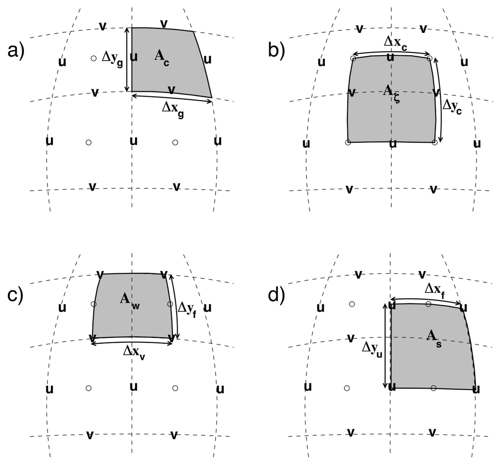

Fig. 2: See caption [here](https://mitgcm.readthedocs.io/en/latest/algorithm/horiz-grid.html) (source: MITgcm doc)

##### **Vertical grid**

The [vertical grid](https://mitgcm.readthedocs.io/en/latest/algorithm/vert-grid.html) is described on the MITgcm website and illustrated in Fig. 3. While the tracers and, the zonal and meridional velocities are located on the cell center, the Gent-McWilliams Bolus meridional transport streamfunction is located on the cell interface. When considering cells near topography, you have to keep in mind that it might be [partially filled](https://mitgcm.readthedocs.io/en/latest/algorithm/vert-grid.html#topography-partially-filled-cells). The thickness of the variable cell is the thickness of the cell ΔrF (that you can find in your grid file) multiplied by a non-dimensional fraction h$_{x}$ (`HFacC`, `HFacW` and `HFacS` that you can find in your grid file, depending on the variable you consider).

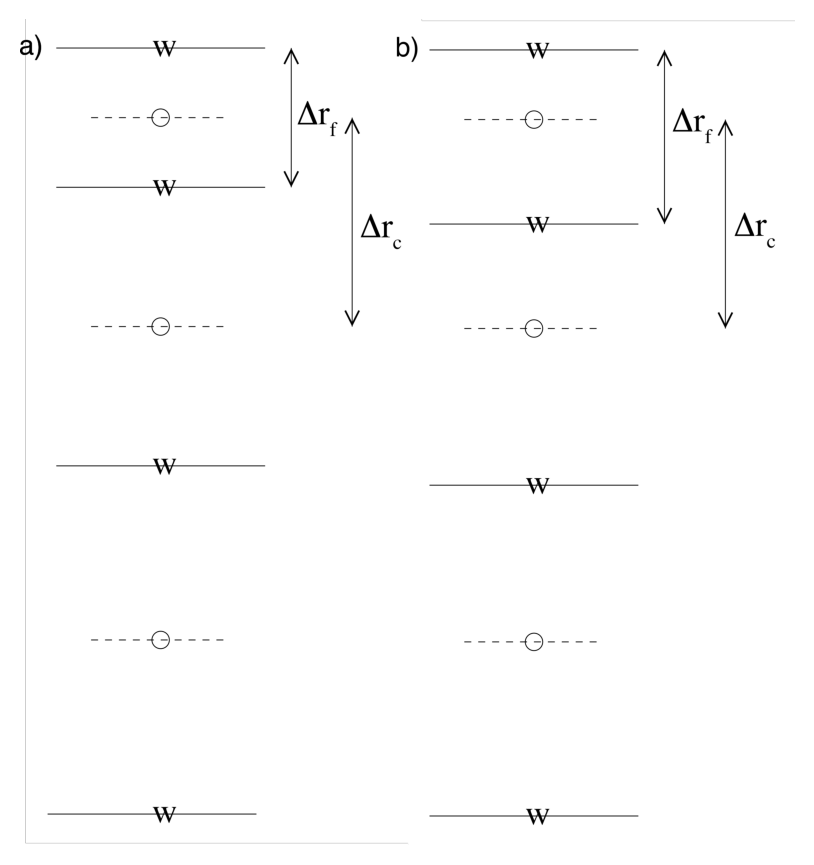

Fig. 3: See caption [here](https://mitgcm.readthedocs.io/en/latest/algorithm/vert-grid.html) (source: MITgcm doc)

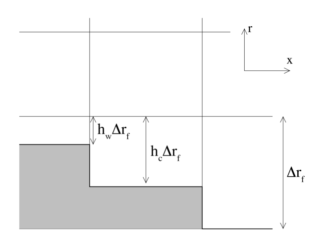

See caption [here](https://mitgcm.readthedocs.io/en/latest/algorithm/vert-grid.html#topography-partially-filled-cells) (source: MITgcm doc)

Take a moment to look at the grid file, by opening for instance `grid.t001.nc` using ncdump:

`ncdump -h grid.t001.nc`

### III.2. Analyses of the output

##### **How to load global variables using MITgcmutils**

In your `MITgcm/my_exp/ctrl` directory, you will find a new directory called `mnc0001`. This directory contains diagnostics files that were generated for each tile. For instance, `Sdiag_MLD.0000036000.t001.nc` and `Sdiag_MLD.0000036000.t002.nc` are the two files containing the mixed layer depth variable, one per tile. Take a quick look at one of these files by typing:

`ncdump -h SDiag_MLD.0000036000.t001.nc`

To analyze the output it is more convenient to reconstruct a full domain (global ocean) from the different tiles. To do so, you can use [MITgcmutils](https://mitgcm.readthedocs.io/en/latest/utilities/utilities.html). `MITgcmutils` is a python package including a number of functions that help deal with model output from the MITgcm. `MITgcmutils` is not installed in the python environment we are using. We can install it at the beginning of a notebook by using a so-called "[magic](https://ipython.readthedocs.io/en/stable/interactive/magics.html)" within the Jupyter notebook as follows

```
%pip install MITgcmutils
```

(Note that the above procedure has to be repeated everytime you re-connect to the JupyterHub and want to use `MITgcmutils`, so it is best practice to run the command at the beginning of each notebook that will use the package. It will be automatically detected if `MITgcmutils` is already installed and the installation will be skipped in that case.)  
Now that the package is installed, we can import and use it. Here is an example of how to load a global variable:

```
# import MITgcmutils
import MITgcmutils
# define path to ctrl simulation
ctrl = '~/MITgcm/my_exp/ctrl/'
# open grid* files and load global X coordinate of cell center
nc = MITgcmutils.mnc_files(ctrl + 'mnc*/grid.t*.nc')
xc = nc.variables['XC'][:]
yc = nc.variables['YC'][:]
nc.close()
# open Diag* files and load global potential temperature
ncv = MITgcmutils.mnc_files(ctrl + 'mnc*/Diag.*.nc')
ptemp = ncv.variables['THETA'][:]
ncv.close()
```

##### **Preliminary analyses**

You can start by plotting surface temperature and salinity, and summer and winter mixed layer depths.

```
from matplotlib import pyplot as plt
plt.pcolormesh(xc, yc, ptemp[9, 0, ...])
```

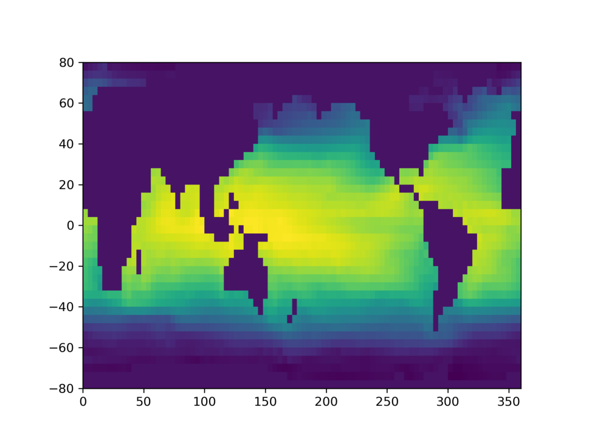